# 1. Overview

**Hypothetical Situation:** You are a data analyst at the online retail company. The company wants to make a marketing campaign to increase sales and brand awareness at the end of the quarter. But they are on a tight budget so the campaign only targets a handful of customers. They ask you to make use of dataset's company and show them which type of customers should the campaign aims at

**Requirement:** As a data analyst of team, it is your mission to perform EDA and do Customer Segmentation to help company make a data-informed decision about the campaign

# 2. Dataset Description

Dataset: https://www.kaggle.com/imakash3011/customer-personality-analysis  
Our hypothetical dataset is from kaggle. It consists of 2240 datapoints and a total of 29 attributes. All the attributes could be divided into sub categories as follows

**Customer's Information**

- ID
- Year_Birth
- Education
- Marital_Status
- Income
- Kidhome
- Teenhome
- Dt_Customer
- Recency
- Complain

**Products**  
Amount of money spent on that product in the last 2 years

- MntWines
- MntFruits
- MntMeatProducts
- MntFishProducts
- MntSweetProducts
- MntGoldProds

**Place**  
Number of purchases customers made on each platform

- NumWebPurchases
- NumCatalogPurchases
- NumStorePurchases
- NumWebVisitsMonth

**Promotion**  
Information about campaigns on each customer. 1 if customer accepted the offer in the nth campaign, 0 otherwise

- NumDealsPurchases
- AcceptedCmp1
- AcceptedCmp2
- AcceptedCmp3
- AcceptedCmp4
- AcceptedCmp5
- Response

# 3. EDA and Data Preprocessing

## 3.1 Overall

**Import needed libraries**

```python
import seaborn as sns
import csv,json,os,statistics,time
import datetime as dt
import numpy as np
import pandas as pd
import requests
import matplotlib.pyplot as plt
from datetime import datetime
import warnings
warnings.filterwarnings("ignore")
pd.set_option('display.max_columns', 8)
```

**Import dataset**

We make a copy of dataset and from now we will only modify it

```python
df_original=pd.read_csv('marketing_campaign.csv')
df_edited=df_original
print(df_edited.info())
print(df_edited.head(3))
```

```
<class 'pandas.core.frame.DataFrame'>
RangeIndex: 2240 entries, 0 to 2239
Data columns (total 29 columns):
 #   Column               Non-Null Count  Dtype
---  ------               --------------  -----
 0   ID                   2240 non-null   int64
 1   Year_Birth           2240 non-null   int64
 2   Education            2240 non-null   object
 3   Marital_Status       2240 non-null   object
 4   Income               2216 non-null   float64
 5   Kidhome              2240 non-null   int64
 6   Teenhome             2240 non-null   int64
 7   Dt_Customer          2240 non-null   object
 8   Recency              2240 non-null   int64
 9   MntWines             2240 non-null   int64
```

[output cut: 33 more lines]

```python
print(df_edited.shape)
df_edited.describe()
```

```
(2240, 29)
```

|  | ID | Year_Birth | Income | Kidhome | ... | Complain | Z_CostContact | Z_Revenue | Response |
| --- | --- | --- | --- | --- | --- | --- | --- | --- | --- |
| count | 2240.000000 | 2240.000000 | 2216.000000 | 2240.000000 | ... | 2240.000000 | 2240.0 | 2240.0 | 2240.000000 |
| mean | 5592.159821 | 1968.805804 | 52247.251354 | 0.444196 | ... | 0.009375 | 3.0 | 11.0 | 0.149107 |
| std | 3246.662198 | 11.984069 | 25173.076661 | 0.538398 | ... | 0.096391 | 0.0 | 0.0 | 0.356274 |
| min | 0.000000 | 1893.000000 | 1730.000000 | 0.000000 | ... | 0.000000 | 3.0 | 11.0 | 0.000000 |
| 25% | 2828.250000 | 1959.000000 | 35303.000000 | 0.000000 | ... | 0.000000 | 3.0 | 11.0 | 0.000000 |
| 50% | 5458.500000 | 1970.000000 | 51381.500000 | 0.000000 | ... | 0.000000 | 3.0 | 11.0 | 0.000000 |
| 75% | 8427.750000 | 1977.000000 | 68522.000000 | 1.000000 | ... | 0.000000 | 3.0 | 11.0 | 0.000000 |
| max | 11191.000000 | 1996.000000 | 666666.000000 | 2.000000 | ... | 1.000000 | 3.0 | 11.0 | 1.000000 |

8 rows × 26 columns

## 3.2 Handling Outliers

In 29 columns, Income is the only numerical column that we need to handle outliers because it will directly affect our clustering analysis.  
Use boxplot to detect outliers

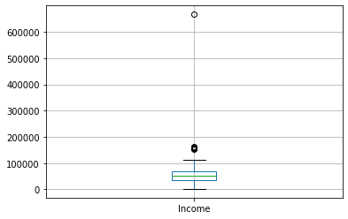

```python
df_edited.boxplot('Income')
```

We can clearly see that the single maximum value of Income (>600000) is an outlier. As a result, we could limit that datapoint to a certain value like 150000 if we have a small dataset, but in this case we can ideally remove it without significant effect on our dataset

```python
df_edited = df_edited.drop(df_edited[df_edited['Income'] > 600000].index)
```

We now have 2239 rows, it shows that the only outlier has been removed successfully

```python
df_edited.shape
```

```
(2239, 29)
```

## 3.3 Handling Missing Values

Only Income column has 24 missing values

```python
# We could use isna() or isnull() to check for missing value
print(df_edited.isnull().any())
print(df_edited.isna().sum())
```

```
ID                     False
Year_Birth             False
Education              False
Marital_Status         False
Income                  True
Kidhome                False
Teenhome               False
Dt_Customer            False
Recency                False
MntWines               False
MntFruits              False
MntMeatProducts        False
MntFishProducts        False
MntSweetProducts       False
MntGoldProds           False
NumDealsPurchases      False
NumWebPurchases        False
NumCatalogPurchases    False
NumStorePurchases      False
NumWebVisitsMonth      False
AcceptedCmp3           False
AcceptedCmp4           False
AcceptedCmp5           False
AcceptedCmp1           False
AcceptedCmp2           False
Complain               False
Z_CostContact          False
Z_Revenue              False
Response               False
dtype: bool
ID                      0
Year_Birth              0
Education               0
Marital_Status          0
Income                 24
Kidhome                 0
Teenhome                0
Dt_Customer             0
Recency                 0
MntWines                0
MntFruits               0
MntMeatProducts         0
MntFishProducts         0
MntSweetProducts        0
MntGoldProds            0
NumDealsPurchases       0
NumWebPurchases         0
NumCatalogPurchases     0
NumStorePurchases       0
NumWebVisitsMonth       0
AcceptedCmp3            0
AcceptedCmp4            0
AcceptedCmp5            0
AcceptedCmp1            0
AcceptedCmp2            0
Complain                0
Z_CostContact           0
Z_Revenue               0
Response                0
dtype: int64
```

Shows the percentage of null values in each column

```python
df_edited.isnull().sum() / df_edited.shape[0]
```

```
ID                     0.000000
Year_Birth             0.000000
Education              0.000000
Marital_Status         0.000000
Income                 0.010719
Kidhome                0.000000
Teenhome               0.000000
Dt_Customer            0.000000
Recency                0.000000
MntWines               0.000000
MntFruits              0.000000
MntMeatProducts        0.000000
MntFishProducts        0.000000
MntSweetProducts       0.000000
MntGoldProds           0.000000
NumDealsPurchases      0.000000
NumWebPurchases        0.000000
NumCatalogPurchases    0.000000
NumStorePurchases      0.000000
NumWebVisitsMonth      0.000000
AcceptedCmp3           0.000000
AcceptedCmp4           0.000000
AcceptedCmp5           0.000000
AcceptedCmp1           0.000000
AcceptedCmp2           0.000000
Complain               0.000000
Z_CostContact          0.000000
Z_Revenue              0.000000
Response               0.000000
dtype: float64
```

We will replace missing data by using imputation method (replaces missing data with mean/median)

```python
df_edited['Income'].fillna(int(df_edited['Income'].mean()), inplace=True)
print(df_edited.isna().sum())
```

```
ID                     0
Year_Birth             0
Education              0
Marital_Status         0
Income                 0
Kidhome                0
Teenhome               0
Dt_Customer            0
Recency                0
MntWines               0
MntFruits              0
MntMeatProducts        0
MntFishProducts        0
MntSweetProducts       0
MntGoldProds           0
NumDealsPurchases      0
NumWebPurchases        0
NumCatalogPurchases    0
NumStorePurchases      0
NumWebVisitsMonth      0
AcceptedCmp3           0
AcceptedCmp4           0
AcceptedCmp5           0
AcceptedCmp1           0
AcceptedCmp2           0
Complain               0
Z_CostContact          0
Z_Revenue              0
Response               0
dtype: int64
```

All missing data has been filled

## 3.4 Feature Engineering and Data Reduction

With nearly 30 columns, we should not try to fit every feature into our cluster analysis model and hope it performs well. So it does make sense for us to extract only essential information from raw data and use it for customer segmentation model

Here is a list of things that we will do for our feature engineering

- Find age from Year_Birth column and Customer's total day of enrollment
- Find total of purchases from Place category
- Find total money spent from Product category and average money per paycheck
- Find total accepted campaign from Campagin category
- Split Marital_Status into 2 main sub categories: Single and In relationship
- Combine Kidhome and Teenhome into only 1 column

### Find age from Year_Birth column and Customer's total day of enrollment

We subtract Year_Birth from current date to find age of customer (age = CurrentDate - Year_Birth)  
We assume the customers's information was reported in the first day of 2015

```python
df_edited['Age']=2015-df_edited['Year_Birth']
df_edited['Age']
```

```
0       58
1       61
2       50
3       31
4       34
        ..
2235    48
2236    69
2237    34
2238    59
2239    61
Name: Age, Length: 2239, dtype: int64
```

Next we find how long a person has been our customer since their enrollment with the company

```python
currentDay=pd.to_datetime('01-01-2015')
df_edited['Dt_Customer'] = pd.to_datetime(df_edited['Dt_Customer'])
df_edited['Days_is_customer']=(currentDay-df_edited['Dt_Customer']).dt.days
```

### Find total of purchases from Place category

```python
df_edited['Total_Purchases']= df_original['NumWebPurchases'] + df_original['NumCatalogPurchases'] + df_original['NumStorePurchases']
df_edited['Total_Purchases']
```

```
0       22
1        4
2       20
3        6
4       14
        ..
2235    16
2236    15
2237    18
2238    21
2239     8
Name: Total_Purchases, Length: 2239, dtype: int64
```

Due to errors in data, 6 customers spent money but none of them make any purchases. I will delete them so they will not affect our model

```python
df_edited = df_edited.drop(df_edited[df_edited['Total_Purchases'] == 0].index)
df_edited.shape
```

```
(2233, 32)
```

### Find total money spent from Product category and average money per paycheck

We calculate sum of all the columns in Product category to find customer's expenses

```python
df_edited['Expenses']= df_edited['MntWines'] + df_edited['MntFruits']
+ df_edited['MntMeatProducts'] + df_edited['MntSweetProducts'] + df_edited['MntFishProducts']
+ df_edited['MntGoldProds']
```

```
0        88
1         6
2        42
3         5
4        15
       ...
2235    247
2236      8
2237     24
2238     61
2239     21
Name: MntGoldProds, Length: 2233, dtype: int64
```

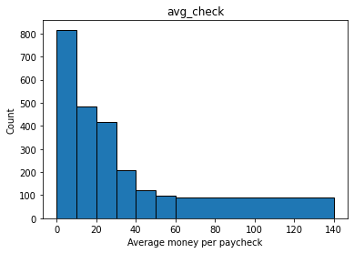

```python
bins=[0,10,20,30,40,50,150]
df_edited['avg_check']=round(df_edited['Expenses']/df_edited['Total_Purchases'])
df_edited.hist('avg_check',bins=[0,10,20,30,40,50,60,140],edgecolor = "black")
plt.grid(b=None)
plt.xlabel('Average money per paycheck')
plt.ylabel('Count')
#plt.xticks(bins.astype('str'))
```

### Find total accepted campaign from Campagin category

```python
df_edited['TotalAcceptedCmp'] = df_edited['AcceptedCmp1'] + df_edited['AcceptedCmp2'] + df_edited['AcceptedCmp3'] + df_edited['AcceptedCmp4'] + df_edited['AcceptedCmp5'] + df_edited['Response']
df_edited['TotalAcceptedCmp']
```

```
0       1
1       0
2       0
3       0
4       0
       ..
2235    0
2236    1
2237    1
2238    0
2239    1
Name: TotalAcceptedCmp, Length: 2233, dtype: int64
```

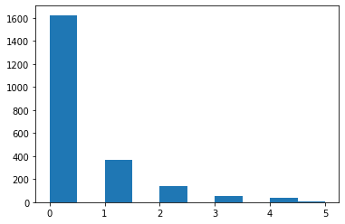

```python
plt.hist(df_edited['TotalAcceptedCmp'])
```

### Split Marital_Status into 2 main sub categories

We need to see all unique values of Marital_Status before deciding how to split them

```python
print(df_edited['Marital_Status'].value_counts())
```

```
Married     862
Together    579
Single      479
Divorced    229
Widow        77
Alone         3
Absurd        2
YOLO          2
Name: Marital_Status, dtype: int64
```

As you can see, 'Married' and 'Together' are clearly 'in relationship' and the rest is 'single'. So we will start to group them

```python
df_edited['Marital_Status'] = df_edited['Marital_Status'].replace(['Married', 'Together'],'In Relationship')
df_edited['Marital_Status'] = df_edited['Marital_Status'].replace(['Divorced', 'Widow', 'Alone', 'YOLO', 'Absurd'],'Single')
print(df_edited['Marital_Status'].value_counts())
```

```
In Relationship    1441
Single              792
Name: Marital_Status, dtype: int64
```

### Combine Kidhome and Teenhome into only 1 column

```
 [Text(0, 0, ''), Text(0, 0, ''), Text(0, 0, ''), Text(0, 0, '')])
```

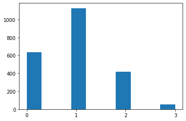

```python
df_edited['Children'] = df_edited['Kidhome'] + df_edited['Teenhome']
plt.hist(df_edited['Children'])
plt.xticks([0,1,2,3])
```

### Finally, we delete excessed columns that we no longer need (Data Reduction)

```python
delColumns = ['Dt_Customer','ID',"AcceptedCmp1" , "AcceptedCmp2", "AcceptedCmp3" , "AcceptedCmp4","AcceptedCmp5", "Response","NumWebVisitsMonth", "NumWebPurchases","NumCatalogPurchases","NumStorePurchases","NumDealsPurchases" , "Kidhome", "Teenhome","MntWines", "MntFruits", "MntMeatProducts", "MntFishProducts", "MntSweetProducts", "MntGoldProds",'Z_CostContact','Z_Revenue','Year_Birth']
df_edited=df_edited.drop(columns=delColumns,axis=1)
```

```python
df_edited.info()
```

```
<class 'pandas.core.frame.DataFrame'>
Int64Index: 2233 entries, 0 to 2239
Data columns (total 12 columns):
 #   Column            Non-Null Count  Dtype
---  ------            --------------  -----
 0   Education         2233 non-null   object
 1   Marital_Status    2233 non-null   object
 2   Income            2233 non-null   float64
 3   Recency           2233 non-null   int64
 4   Complain          2233 non-null   int64
 5   Age               2233 non-null   int64
 6   Days_is_customer  2233 non-null   int64
 7   Total_Purchases   2233 non-null   int64
 8   Expenses          2233 non-null   int64
 9   avg_check         2233 non-null   float64
 10  TotalAcceptedCmp  2233 non-null   int64
 11  Children          2233 non-null   int64
dtypes: float64(2), int64(8), object(2)
memory usage: 226.8+ KB
```

## 3.5 Data Insight

We know a lot about our customers thanks to feature engineering and EDA, I will point out few noticeable details that we can use for report or help the company with marketing campaign

```
<BarContainer object of 6 artists>
```

[figure not shown]

```python
product_category=['MntWines',"MntFruits", "MntMeatProducts", "MntFishProducts", "MntSweetProducts", "MntGoldProds"]
product_df=df_original[product_category]

# Rearrange order of columns based on their sum
label=['Wine','Fruit','Meat','Fish','Sweet','Gold']
product_df=product_df[product_df.sum().sort_values(ascending = False).index]
f, ax = plt.subplots(figsize=(9,6))
plt.ylabel('Total expenses')
plt.bar(label,product_df.sum())
```

[figure not shown]

```python
f, ax = plt.subplots(figsize=(9,6))
plt.pie(product_df.sum(), startangle = 90,labels = label,autopct='%1.1f%%')
plt.legend()
```

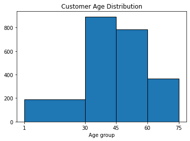

```python
plt.hist(df_edited['Age'],bins=[1,30,45,60,75],edgecolor = "black")
plt.xticks([1,30,45,60,75])
plt.title('Customer Age Distribution')
plt.xlabel('Age group')
```

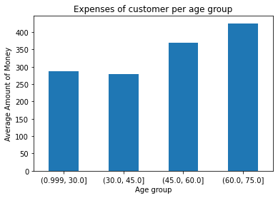

```python
df_edited["Age_Group"] = pd.cut(df_edited["Age"],  bins=[1,30,45,60,75],include_lowest=True)
df_edited.groupby("Age_Group").mean()['Expenses'].plot(kind='bar')
plt.xticks(rotation=0)
plt.title('Expenses of customer per age group')
plt.ylabel('Average Amount of Money')
plt.xlabel('Age group')
```

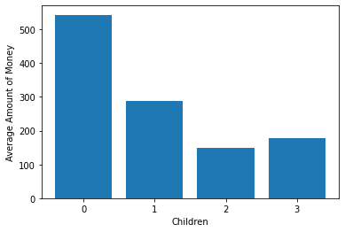

```python
expenses_children=df_edited.groupby('Children').mean()['Expenses']
plt.bar([0,1,2,3],expenses_children)
plt.xticks([0,1,2,3])
plt.xlabel('Children')
plt.ylabel('Average Amount of Money')
```

**Insight**: Customers with less children tend to spend more amount of money

# 4. Customer Segmentaion

**Import needed libraries for cluster analysis model**

We will use K-Mean algorithm to group similar customers together and discover underlying pattern

```python
from sklearn.preprocessing import StandardScaler
from sklearn.cluster import KMeans
from sklearn.metrics import silhouette_samples, silhouette_score
import matplotlib.colors
import random
```

## a. Feature Standardization

K-Mean often uses Euclidean Distance to form a group, if we do not standarize before feeding numerical features to ML algorithm then our model will be dominated or heavily biased by a feature with large scale  
For example: Income column has larger value than the rest, so it will be dominated in model if we don't perform standarization

```python
sc = StandardScaler()
df_edited=df_edited.select_dtypes(include='number')
df_edited_scaled = pd.DataFrame(sc.fit_transform(df_edited),columns = df_edited.columns,index=df_edited.index)
df_edited_scaled
```

|  | Income | Recency | Complain | Age | ... | Expenses | avg_check | TotalAcceptedCmp | Children |
| --- | --- | --- | --- | --- | --- | --- | --- | --- | --- |
| 0 | 0.292465 | 0.307166 | -0.097435 | 0.984997 | ... | 1.106616 | 0.700602 | 0.618950 | -1.266472 |
| 1 | -0.266219 | -0.383292 | -0.097435 | 1.235215 | ... | -0.901842 | -0.927727 | -0.502897 | 1.395205 |
| 2 | 0.930778 | -0.797567 | -0.097435 | 0.317750 | ... | 0.406057 | 0.212103 | -0.502897 | -1.266472 |
| 3 | -1.199317 | -0.797567 | -0.097435 | -1.266964 | ... | -0.893368 | -0.982005 | -0.502897 | 0.064367 |
| 4 | 0.299808 | 1.549990 | -0.097435 | -1.016746 | ... | -0.325576 | -0.276395 | -0.502897 | 0.064367 |
| ... | ... | ... | ... | ... | ... | ... | ... | ... | ... |
| 2235 | 0.438602 | -0.107109 | -0.097435 | 0.150938 | ... | 1.188536 | 1.460489 | -0.502897 | 0.064367 |
| 2236 | 0.570812 | 0.238120 | -0.097435 | 1.902463 | ... | 0.211143 | 0.374936 | 0.618950 | 2.726043 |
| 2237 | 0.237658 | 1.446422 | -0.097435 | -1.016746 | ... | 1.764803 | 1.786155 | 0.618950 | -1.266472 |
| 2238 | 0.818606 | -1.418980 | -0.097435 | 1.068403 | ... | 0.358034 | 0.103548 | -0.502897 | 0.064367 |
| 2239 | 0.042872 | -0.314247 | -0.097435 | 1.235215 | ... | -0.689980 | -0.493506 | 0.618950 | 1.395205 |

2233 rows × 10 columns

We can see that the data has been scaled successfully

## b. Feature Selection

Feature Selection is one of the most important tasks in customer segmentation problem. Different features affect clusters differently, some features are vital for clusters while the others may not be so important as you think  
In this section, I will choose features based on several common characteristics of customer like:

- Demographic: includes personal information such as income, gender, race, nationality, occupation,...
- Geographic: includes climate, city or country, population density,..
- Psychographic: includes customer’s personality and preferences like attitudes, opinions, values, interests, lifestyle and motivations
- Behavioral: The way a customer behaves affects how they interact with businesses, includes purchasing habits, brand loyalty,..

```python
df_feats=df_edited_scaled[['Income', 'Days_is_customer', 'avg_check']].copy()
```

Based on 4 characteristics above, I decided to choose Income (Demographic), Days_is_customer (Behavioral), avg_check (Psychographic) columns as features for K-Mean algorithm

## c. Find optimal number of clusters by Silhoutte Method

The number of clusters plays an important role in customer segmentation, we don't want to have too much (hard to focus) or too little (lack of details) groups of customer  
In order to perform well in clustering, we want to minimize the distance between datapoints within a cluster to its centroid (increase compactness of cluster) and there are 2 main techniques that we can help us with that: The elbow method and Silhoutte method. If you want to find out more about these 2 methods, just click the link below  
https://vitalflux.com/elbow-method-silhouette-score-which-better/#:~:text=The%20major%20difference%20between%20elbow,high%2Dlow%20differences%2C%20etc.

```python
# Calculate Silhoutte score for each number of clusters
scoreList=[]
n=10
clusterNum=list(range(2,n))
for n_clusters in range(2,n):
    km = KMeans(n_clusters=n_clusters,init = 'k-means++')
    preds = km.fit_predict(df_feats)
    labels=km.labels_
    #centers = clusterer.cluster_centers_

    score = silhouette_score(df_feats, preds)
    scoreList.append(score)
    print("For n_clusters = {}, silhouette score is {})".format(n_clusters, round(score,3)))
```

```
For n_clusters = 2, silhouette score is 0.357)
For n_clusters = 3, silhouette score is 0.31)
For n_clusters = 4, silhouette score is 0.316)
For n_clusters = 5, silhouette score is 0.321)
For n_clusters = 6, silhouette score is 0.296)
For n_clusters = 7, silhouette score is 0.297)
For n_clusters = 8, silhouette score is 0.281)
For n_clusters = 9, silhouette score is 0.289)
```

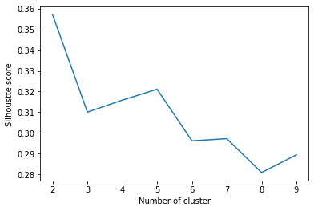

```python
plt.plot(clusterNum,scoreList)
plt.xlabel('Number of cluster')
plt.ylabel('Silhoustte score')
```

## d. Model building and visualization

### Model building and clusters's distribution

```python
# Number of clusters
k=4
km = KMeans(n_clusters=k,init='k-means++',random_state=42)

# Fit and predict label
preds = km.fit_predict(df_feats)
df_edited['Customer_Type']=preds
df_edited['Customer_Type'].value_counts().sort_index()
```

```
0    637
1    578
2    374
3    644
Name: Customer_Type, dtype: int64
```

```python
def addlabels(x,y):
    total=sum(y)
    for i in range(len(x)):
        myStr=str(y[i])+' | '+str(round(y[i]*100/total,1))+'%'
        plt.text(i,y[i]//2,myStr,ha = 'center')
```

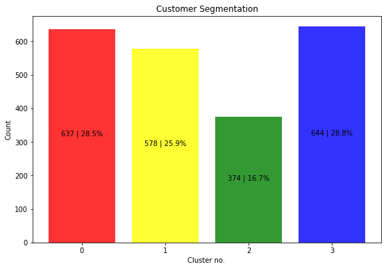

```python
clusters=list(range(k))
y=df_edited['Customer_Type'].value_counts().sort_index()
colors=('red','yellow','green','blue','gray')
plt.figure(figsize = (9,6))
plt.bar(clusters,y,color=colors,alpha=0.8)
plt.xticks(clusters)
plt.xlabel('Cluster no. ')
plt.ylabel('Count')
plt.title('Customer Segmentation')
addlabels(clusters, y)
```

### K-Mean Cluster 3D Plot

```python
# You can create n random color use this function
def createRandomColor(n):
    number_of_colors  = ["#"+''.join([random.choice('0123456789ABCDEF') for j in range(6)])
             for i in range(n)]
    return number_of_colors

# Or if you want don't want random, just use this color palette
colors=['#FAD3AE', '#855E46', '#FE800F', '#890000']
cmap = matplotlib.colors.ListedColormap(colors)
```

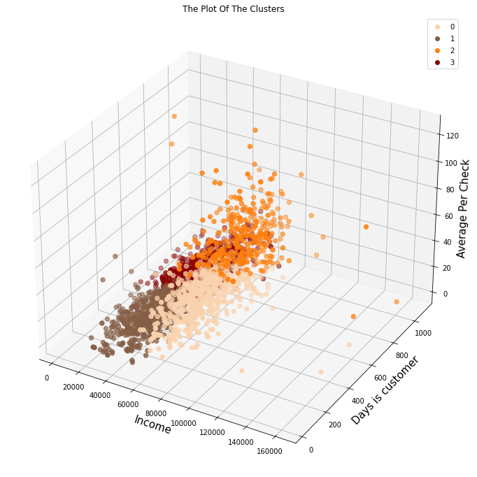

```python
#Plotting the clusters
x=df_edited['Income']
y=df_edited['Days_is_customer']
z=df_edited['avg_check']

fig = plt.figure(figsize=(15,12))
ax = plt.subplot(111, projection='3d', label="bla")
sc=ax.scatter(x, y, z, s=40, c=df_edited['Customer_Type'], marker='o', cmap = cmap )
ax.set_title("The Plot Of The Clusters")
ax.set_xlabel('Income',fontsize=15)
ax.set_ylabel('Days is customer',fontsize=15)
ax.set_zlabel('Average Per Check',fontsize=15)
plt.legend(*sc.legend_elements())
```

### Naming Customer Segments

After finishing clustering, we should give each cluster a meaningful name to identify between them, this could be based on their characteristic features like Income, spending habit,...

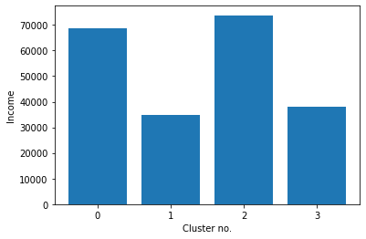

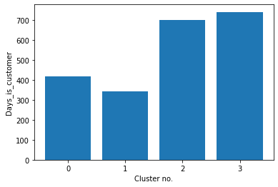

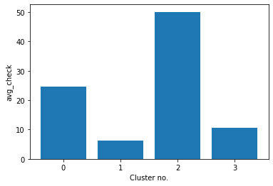

```python
features=['Income', 'Days_is_customer', 'avg_check']
for feat in features:
    y=df_edited.groupby('Customer_Type').mean()[feat]
    plt.bar(clusters,y)
    plt.xticks(clusters)
    plt.xlabel('Cluster no.')
    plt.ylabel(feat)
    plt.show()
```

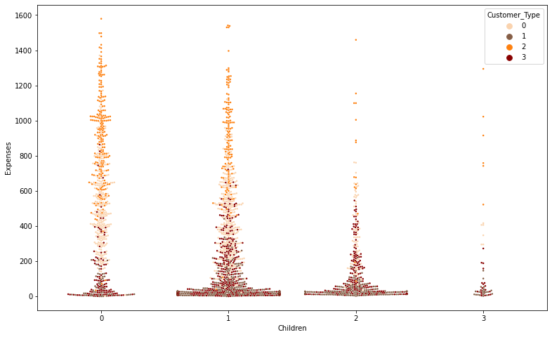

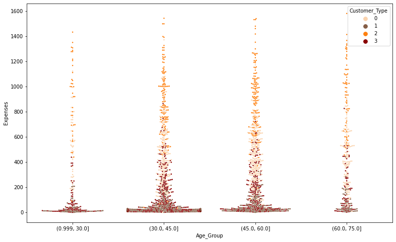

```python
df_edited["Age_Group"] = pd.cut(df_edited["Age"],  bins=[1,30,45,60,75],include_lowest=True)
prf = ["Children", "Age_Group"]
for i in prf:
    plt.figure(figsize=(13,8))
    sns.swarmplot(x=i, y="Expenses", hue="Customer_Type", palette=colors ,data=df_edited,size=2.5)
```

# 5. Conclusion

We have gone through pretty much entire part of customer segmentation project (EDA, Data Cleaning, Model building,etc). As a data analyst, you can use these clusters for implementing strategy and sending the appropriate campaign. It is up to you and your stakeholders to intepret and decide a a direction for marking campagin.  
Thanks for reading my project and have a great day !